# ex8

## 1. heart disease

The data: for each age xi, mi = nb of individuals of age xi, Ni=nb of individuals with heart disease among mi.

Goal: estimate P(have heart disease) = function of age i.

```r
heart.dat <- read.table("http://stat.ethz.ch/Teaching/Datasets/heart.dat", header=T)
```

### b) contour plot of negative log-likelihood function neg.ll(beta0, beta1)

function to calculate the neg LL of data:

```r
# beta: c(beta0, beta1)
# data: dataframe with col=(age, m, N)
neg.ll <- function(beta, data){
  lli <- log(choose(data$m, data$N)) +
    data$N * (beta[1]+beta[2]*data$age) -
    data$m*log(1+exp(beta[1]+beta[2]*data$age)) # LL for ith observation
  -sum(lli)
}
```

plot the contour: * we compute the -LL(beta) for a beta grid of 101x101 (10000 values), store them into a matrix of shape 101x101. * use the param `levels` to control the contour picture: dense in level=50~200, sparse in level 300~2300

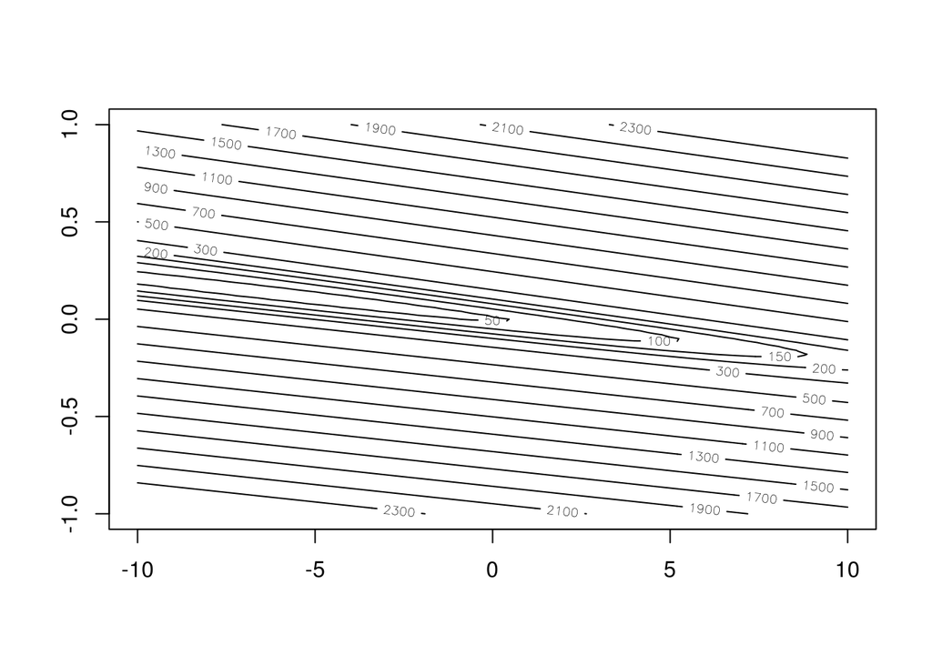

```r
beta0.grid <- seq(-10, 10, length = 101)
beta1.grid <- seq(-1, 1, length=101)
beta.grid <- cbind(beta0.grid, beta1.grid) # shape = 101*2
neg.ll.values <- matrix(0, nrow=101, ncol=101)
for(i in 1:101)
  for(j in 1:101)
    neg.ll.values[i,j] <- neg.ll(c(beta0.grid[i], beta1.grid[j]), heart.dat)
contour(beta0.grid, beta1.grid, neg.ll.values,
         levels=c(seq(50,200,50),seq(300,2300,200)))
```

### c) estimate param using glm

use the R-hint in pb:

```r
fit <- glm(cbind(N, m - N) ~ age, family = binomial, data = heart.dat)
summary(fit)
```

```
##
## Call:
## glm(formula = cbind(N, m - N) ~ age, family = binomial, data = heart.dat)
##
## Deviance Residuals:
##      Min        1Q    Median        3Q       Max
## -1.36404  -0.54656   0.02468   0.55254   1.53533
##
## Coefficients:
##             Estimate Std. Error z value Pr(>|z|)
## (Intercept)  -5.0993     1.1090  -4.598 4.26e-06 ***
## age           0.1084     0.0238   4.555 5.24e-06 ***
## ---
## Signif. codes:  0 '***' 0.001 '**' 0.01 '*' 0.05 '.' 0.1 ' ' 1
##
## (Dispersion parameter for binomial family taken to be 1)
##
##     Null deviance: 53.466  on 42  degrees of freedom
## Residual deviance: 25.153  on 41  degrees of freedom
## AIC: 63.888
##
## Number of Fisher Scoring iterations: 4
```

remark: >beta_hat = [-5.0993, 0.1084] >The infulence of the age is significant (p-value<0.001), the sign of beta_1 is positive meaning the logit increase with age, so the proba of heart disease is also increasing in age.

```r
optim(c(0, 0), neg.ll, data = heart.dat)
```

```
## $par
## [1] -5.0990932  0.1083889
##
## $value
## [1] 29.9438
##
## $counts
## function gradient
##       81       NA
##
## $convergence
## [1] 0
##
## $message
## NULL
```

> beta_hat = [-5.0990932, 0.1083889], almost the same result.

### d) plot proba_hat~age, and get quantile

Plot the fit, to compute the quantile, do NOT use `quantile`, instead derive the inverse function: age=function(proba) :

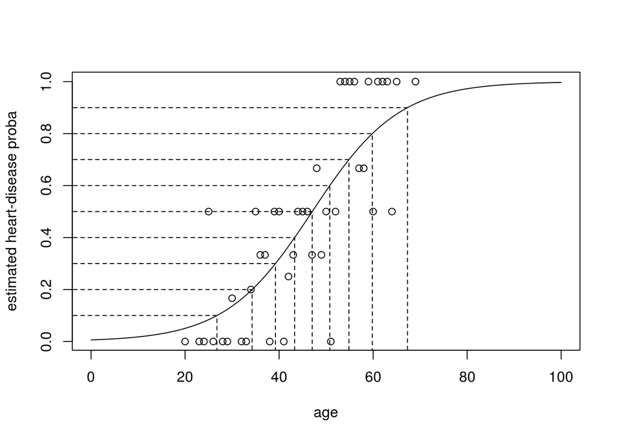

```r
new.age <- seq(0, 100, length=200)
new.pred <- predict(fit, newdata = data.frame(age = new.age), type = "response")
plot( new.age, new.pred,
      type="l", xlab="age", ylab="estimated heart-disease proba")
points(heart.dat$age, heart.dat$N/heart.dat$m)

beta_hat <-  c(-5.0993, 0.1084)
perc <- (1:9)/10
age.qtl <- (log(perc/(1-perc)) - beta_hat[1]) / beta_hat[2]
for(i in 1:9)
  lines( c(-10, age.qtl[i], age.qtl[i]), c(perc[i], perc[i], -1), lty=2)
```

## 2. ozone

cannot install gss?

```
/usr/bin/ld: cannot find -llapack
collect2: error: ld returned 1 exit status
/usr/share/R/share/make/shlib.mk:6: recipe for target 'gss.so' failed
make: *** [gss.so] Error 1
```

==> `sudo apt install liblapack-dev`

```r
# install.packages("gss")
library(gss)
data(ozone, package="gss")
help(ozone, package="gss")
```

### a) overview of data

log-transform the upo3, and remove outliers in wdsp. And have a look at the `pairs` function To get the index of the outlier, use `which.max`:

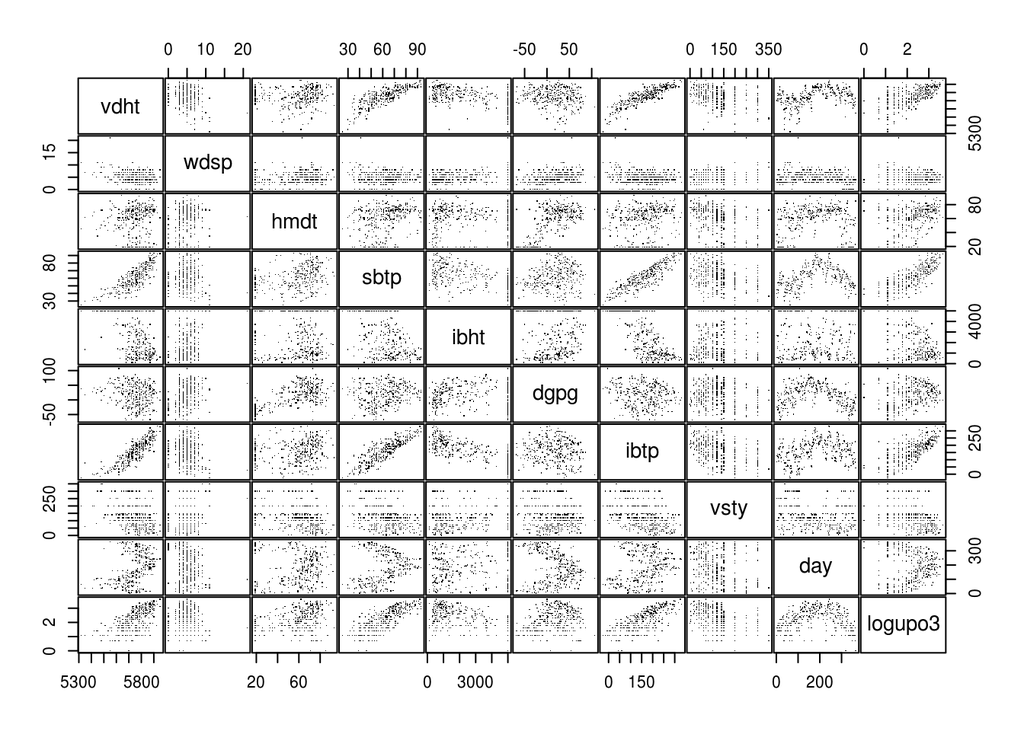

```r
ozone$logupo3 <- log(ozone$upo3)
d.ozone <- subset(ozone, select=-upo3)
pairs(d.ozone, pch = ".",gap = 0.1)
```

```r
## delete outlier
out <- which.max(d.ozone$wdsp)
d.ozone.e <- d.ozone[-out,]
```

remarks:  
>To avoid heteroscedastic errors, we take the log-tranform of upo3.

### b) linear regression of degree=5, and additive model

For additive model, see setion 7.2 in notes.

```r
## package for formula
require(sfsmisc)
## Linear models
## fit 1 (polynomial of degree 1)
form1 <- logupo3~.
fit1 <- lm(form1, data=d.ozone.e)


## fits of degree 2 to 5
form2 <- wrapFormula(form1, data=d.ozone.e, wrapString="poly(*,degree=2)")
fit2 <- lm(form2, data=d.ozone.e)
form3 <- wrapFormula(form1, data=d.ozone.e, wrapString="poly(*,degree=3)")
fit3 <- lm(form3, data=d.ozone.e)
form4 <- wrapFormula(form1, data=d.ozone.e, wrapString="poly(*,degree=4)")
fit4 <- lm(form4, data=d.ozone.e)
form5 <- wrapFormula(form1, data=d.ozone.e, wrapString="poly(*,degree=5)")
fit5 <- lm(form5, data=d.ozone.e)


## GAM
# install.packages("mgcv")
require(mgcv)
gamForm <- wrapFormula(form1, data=d.ozone.e)
g1 <- gam(gamForm, data=d.ozone.e)
summary(g1)
```

```
##
## Family: gaussian
## Link function: identity
##
## Formula:
## logupo3 ~ s(vdht) + s(wdsp) + s(hmdt) + s(sbtp) + s(ibht) + s(dgpg) +
##     s(ibtp) + s(vsty) + s(day)
##
## Parametric coefficients:
##             Estimate Std. Error t value Pr(>|t|)
## (Intercept)   2.2148     0.0172   128.8   <2e-16 ***
## ---
## Signif. codes:  0 '***' 0.001 '**' 0.01 '*' 0.05 '.' 0.1 ' ' 1
##
## Approximate significance of smooth terms:
##           edf Ref.df      F  p-value
## s(vdht) 1.000  1.000 10.878 0.001087 **
## s(wdsp) 1.046  1.090  8.856 0.003093 **
## s(hmdt) 2.372  2.983  2.454 0.057053 .
## s(sbtp) 3.855  4.803  4.155 0.001426 **
## s(ibht) 2.785  3.407  5.386 0.000969 ***
## s(dgpg) 3.267  4.153 14.380 4.95e-11 ***
## s(ibtp) 1.000  1.000  0.441 0.507315
## s(vsty) 5.513  6.671  6.088 2.21e-06 ***
## s(day)  4.616  5.741 25.029  < 2e-16 ***
## ---
## Signif. codes:  0 '***' 0.001 '**' 0.01 '*' 0.05 '.' 0.1 ' ' 1
##
## R-sq.(adj) =  0.826   Deviance explained =   84%
## GCV = 0.10579  Scale est. = 0.097287  n = 329
```

### c) plot the fits

Plot for the linear models.

In the function `termplot`, it’s possible to plot the pointwise residuals by setting `partial.resid`:

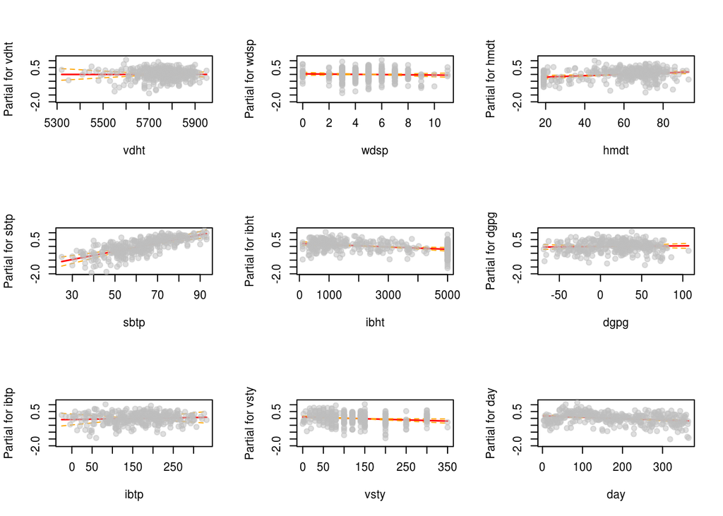

```r
## plot the fits
par(mfrow=c(3,3))
termplot(fit1, partial.resid=T, col.res=adjustcolor("gray", 0.5), # plot pointwise residuals
         se=T, pch=19, ask=F)
```

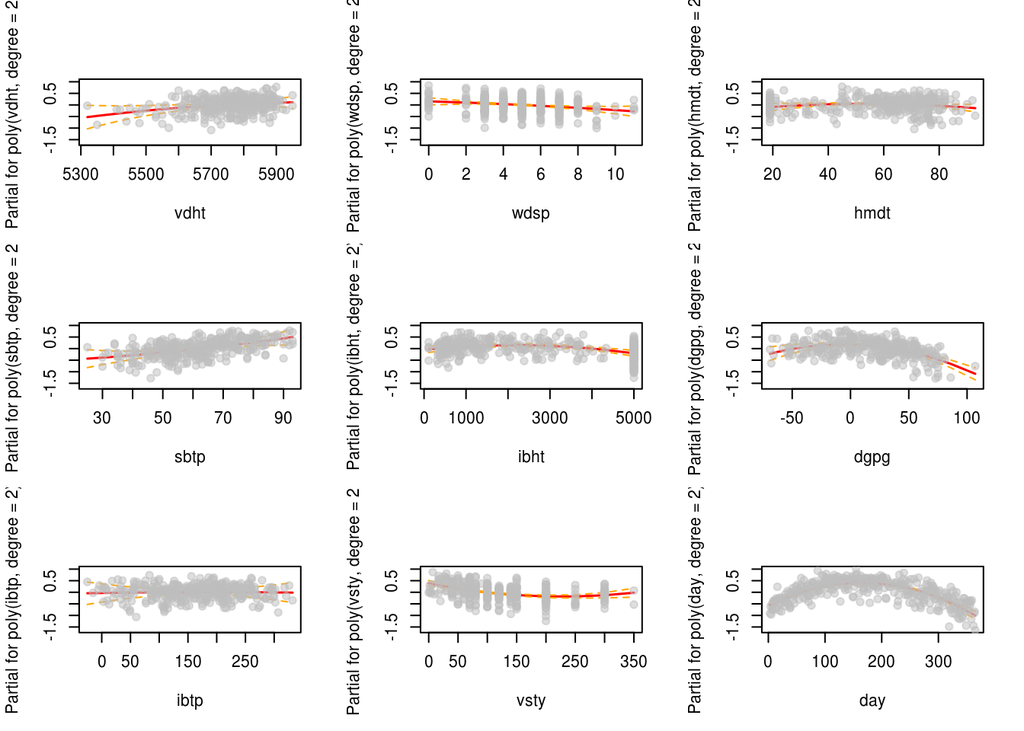

```r
termplot(fit2, partial.resid=T, col.res=adjustcolor("gray", 0.5),
         se=T, pch=19, ask=F)
```

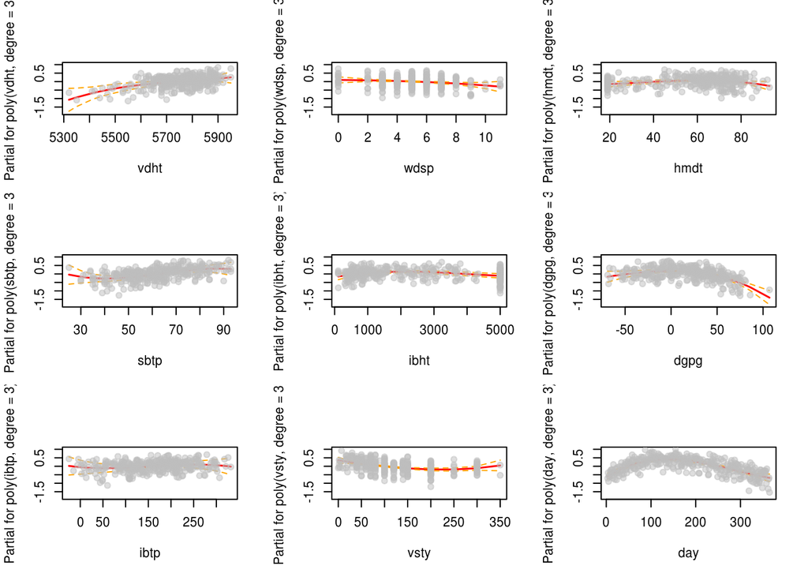

```r
termplot(fit3, partial.resid=T, col.res=adjustcolor("gray", 0.5),
         se=T, pch=19, ask=F)
```

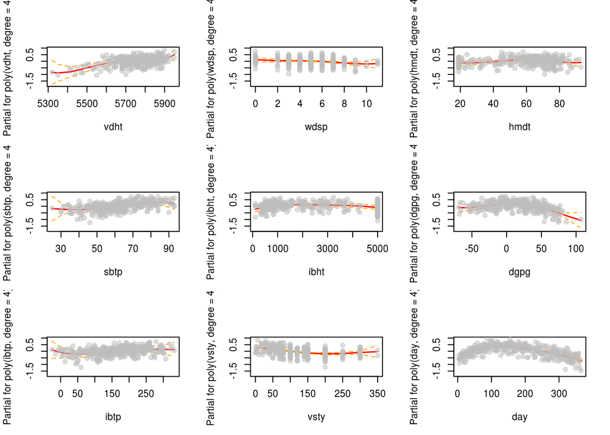

```r
termplot(fit4, partial.resid=T, col.res=adjustcolor("gray", 0.5),
         se=T, pch=19, ask=F)
```

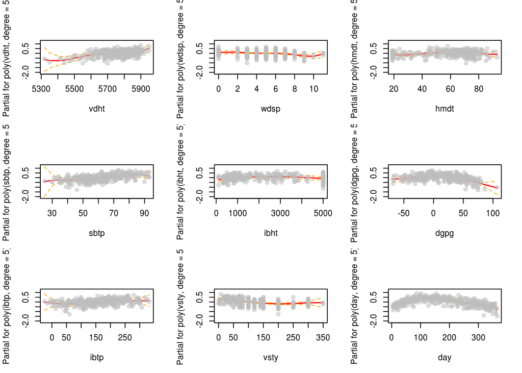

```r
termplot(fit5, partial.resid=T, col.res=adjustcolor("gray", 0.5),
         se=T, pch=19, ask=F)
```

Remarks:  
>the plot for deg=3,4,5 don’t differ much, a ploy of deg=2 is already a good fit, we choose d=2 as it is not too complicated, but model selection by eye is not the best practice.

Plot fit for the additive model:

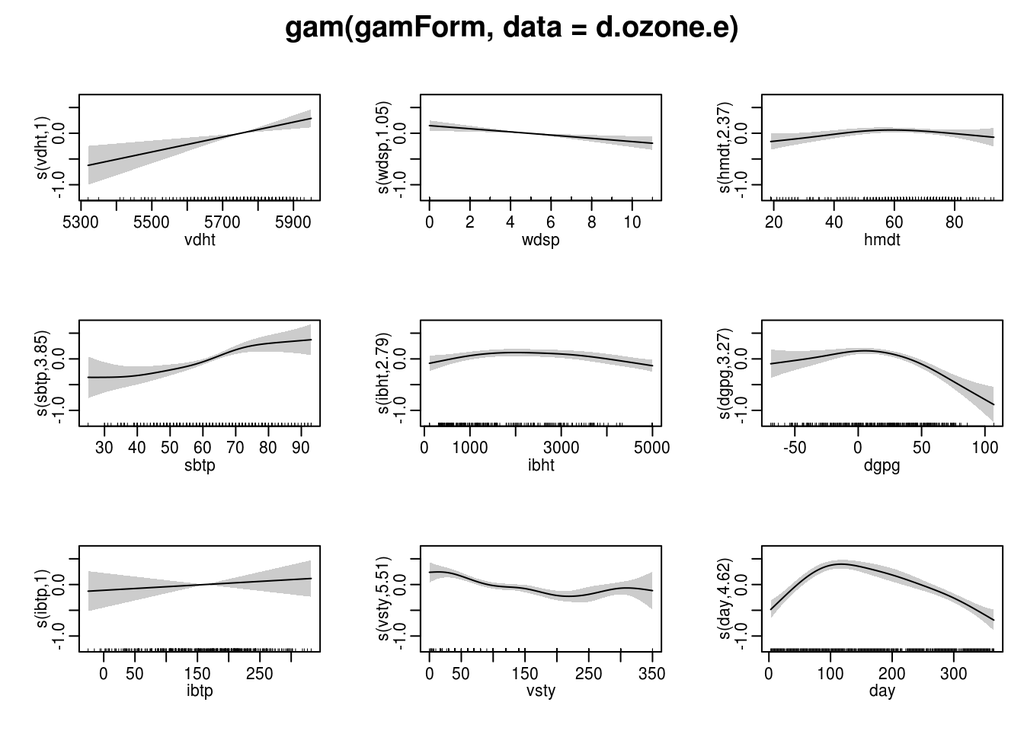

```r
require(sfsmisc)
mult.fig(nr.plots = 9, main="gam(gamForm, data = d.ozone.e)")
plot(g1, shade = TRUE)
```

### d) model selection using Mallows Cp

```r
## Mallows Cp function
Cp <- function(object,sigma=summary(fit5)$sigma){
  res<-residuals(object)
  n <- length(res)
  p <- n-object$df.residual
  SSE <- sum(res^2)
  SSE/sigma^2-n+2*p
}
```

The param sigma is in `summary(fit5)$sigma`

```r
c(Cp(fit1), Cp(fit2), Cp(fit3), Cp(fit4), Cp(fit5), Cp(g1))
```

```
## [1] 209.06499  40.80239  31.53408  33.30466  46.00000  16.82841
```